# SDS HW1

Vlado Vukovic

11/5/2017

## Question 1

My assumptions are that Rome has population of 1,486,981 people, and one phone number is available per 4 people (avg family) + one phone number per 1,000 people for other stuff like businesses or government.

Line busyness is a normal random variable with mean 0.2 and sd 0.1.

```r
pop = 1486981
totalNumbers = pop / 4 +  pop /1000
probBusy = rnorm(1,0.2,0.1)
prior = 1 / totalNumbers
post = 1 / (totalNumbers*probBusy)
cat("My belief was", prior, "\n")
```

```
## My belief was 2.679297e-06
```

```r
cat("My belief after dialing is", post, "\n")
```

```
## My belief after dialing is 9.411369e-06
```

```r
cat("Therefore my belief increased by", post/prior, "times")
```

```
## Therefore my belief increased by 3.512626 times
```

## Question 2

### Part 1

```r
result <- function(game) {
  w <- array(0, dim=c(1,2))

  row1 = game[1] + game[2] + game[3]
  if (row1 == 0) {w[1] <- 1} else if (row1 == 3) {w[2] <- 1}

  row2 = game[4] + game[5] + game[6]
  if (row2 == 0) {w[1] <- 1} else if (row2 == 3) {w[2] <- 1}

  row3 = game[7] + game[8] + game[9]
  if (row3 == 0) {w[1] <- 1} else if (row3 == 3) {w[2] <- 1}

  col1 = game[1] + game[4] + game[7]
  if (col1 == 0) {w[1] <- 1} else if (col1 == 3) {w[2] <- 1}

  col2 = game[2] + game[5] + game[8]
  if (col2 == 0) {w[1] <- 1} else if (col2 == 3) {w[2] <- 1}

  col3 = game[3] + game[6] + game[9]
  if (col3 == 0) {w[1] <- 1} else if (col3 == 3) {w[2] <- 1}

  diag1 = game[1] + game[5] + game[9]
  if (diag1 == 0) {w[1] <- 1} else if (diag1 == 3) {w[2] <- 1}

  diag2 = game[3] + game[5] + game[7]
  if (diag2 == 0) {w[1] <- 1} else if (diag2 == 3) {w[2] <- 1}

  if(w[1] == 0 & w[2] == 0) {return("t")} #reprint("Its a tie")
  if(w[1] == 1 & w[2] == 0) {return("o")} #print("O wins")}
  if(w[1] == 0 & w[2] == 1) {return("x")} #print("X wins")}
  if(w[1] == 1 & w[2] == 1) {return("t")} #print("Its a tie")}
}

res <- array(NA, dim=c(1,1000))
for (k in 1:1000) {
  first = matrix(NA,3,3)
  for (i in 1:9){
    first[i]= rbinom(1,1,0.5)
  }
  res[k] <- result(first)
}
t <- sum(res == "t")
o <- sum(res == "o")
x <- sum(res == "x")
cat("Out of 1,000 games: X won", x, ", O won", o, "and there were", t, "ties")
```

```
## Out of 1,000 games: X won 395 , O won 366 and there were 239 ties
```

```r
cat("Therefore probability that X wins is :", (x/1000))
```

```
## Therefore probability that X wins is : 0.395
```

### Part 2

```r
result1 <- function(game) {
  w <- array(0, dim=c(1,2))
  row1 = game[1] + game[2] + game[3]
  if (row1 == 0) {w[1] <- 1}
  row2 = game[4] + game[5] + game[6]
  if (row2 == 0) {w[1] <- 1}
  row3 = game[7] + game[8] + game[9]
  if (row3 == 0) {w[1] <- 1}
  col1 = game[1] + game[4] + game[7]
  if (col1 == 0) {w[1] <- 1}
  col2 = game[2] + game[5] + game[8]
  if (col2 == 0) {w[1] <- 1}
  col3 = game[3] + game[6] + game[9]
  if (col3 == 0) {w[1] <- 1}
  diag1 = game[1] + game[5] + game[9]
  if (diag1 == 0) {w[1] <- 1}
  diag2 = game[3] + game[5] + game[7]
  if (diag2 == 0) {w[1] <- 1}
  if(w[1] == 1) {return("o")} #print("O wins")}
}

result2 <- function(game) {
  w <- array(0, dim=c(1,2))
  row1 = game[1] + game[2] + game[3]
  if (row1 == 3) {w[2] <- 1}
  row2 = game[4] + game[5] + game[6]
  if (row2 == 3) {w[2] <- 1}
  row3 = game[7] + game[8] + game[9]
  if (row3 == 3) {w[2] <- 1}
  col1 = game[1] + game[4] + game[7]
  if (col1 == 3) {w[2] <- 1}
  col2 = game[2] + game[5] + game[8]
  if (col2 == 3) {w[2] <- 1}
  col3 = game[3] + game[6] + game[9]
  if (col3 == 3) {w[2] <- 1}
  diag1 = game[1] + game[5] + game[9]
  if (diag1 == 3) {w[2] <- 1}
  diag2 = game[3] + game[5] + game[7]
  if (diag2 == 3) {w[2] <- 1}
  if(w[2] == 1) {return("x")} #print("X wins")}
}

res1 <- array(NA, dim=c(1,1000))
for (j in 1:1000) {
  second = matrix(100,3,3)
  allCells <- seq(1:9)
  remaining <- allCells
  for (i in 1:9){
    selected <- sample(remaining,1,replace=FALSE)
    if (i == 9) {
        selected <- remaining
    }
    remaining <- setdiff(remaining,selected)
    if (i %% 2 == 0) {
      second[selected] <- 0
      if (length(result1(second)) > 0) {
        res1[j] <- result1(second)
        break
      }
    }
    else {
      second[selected] <- 1
      if (length(result2(second)) > 0) {
        res1[j] <- result2(second)
        break
        }
    }
  }
}
res1[is.na(res1)] <- "t"
t1 <- sum(res1 == "t")
o1 <- sum(res1 == "o")
x1 <- sum(res1 == "x")
cat("Out of 1,000 games: X won", x1, ", O won", o1, "and there were", t1, "ties")
```

```
## Out of 1,000 games: X won 584 , O won 297 and there were 119 ties
```

```r
cat("Therefore probability that X wins is :", (x1/1000))
```

```
## Therefore probability that X wins is : 0.584
```

```r
cat("while probability that O wins is :", (o1/1000))
```

```
## while probability that O wins is : 0.297
```

## Question 3

Monty Hall works because we initially assign .66 probability to doors that we dont pick, upon switching (opening one of the doors) the probability of .66 remains (on paper) on the remaining one door, hence we should always switch. Which is also confirmed through simulation below.

Therefore it doesnt matter what we initially choose, we should switch in the long run although we loose when we pick door with car which is 0.33.

```r
doors <- c("A","B","C")
decision <- c()
for (i in 1:1000)
{
  prize <- sample(doors)[1]
  pick <- sample(doors)[1]
  open <- sample(doors[which(doors != prize & doors != pick)])[1]
  switch <- doors[which(doors != pick & doors != open)]
  if(pick == prize){decision=c(decision,"NoSwitch")}
  if(switch == prize){decision=c(decision,"Switch")}
}
cat("Switching was appropriate strategy in :", (length(which(decision == "NoSwitch"))/1000), "of times")
```

```
## Switching was appropriate strategy in : 0.352 of times
```

```r
cat("Switching was appropriate strategy in :", (length(which(decision == "Switch"))/1000), "of times")
```

```
## Switching was appropriate strategy in : 0.648 of times
```

## Question 4

### Part 1

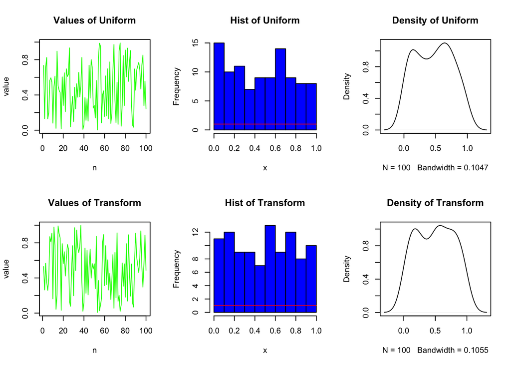

```r
xx <- runif(100,0,1)
y <- array(NA, dim=c(1,100))
for(i in 1:100) {
  x <- xx[i]
  if (x <= 0.5) {
    x <- 2*x
  }
  else {
    x <- 2*(1-x)
  }
  y[i] <- x
}

x <- xx
par(mfrow=c(2,3))
plot(seq(1:100),x, type = 'l',col="Green", xlab="n", ylab="value", main="Values of Uniform")
hist(x, breaks=10, col="blue", main="Hist of Uniform")
curve(dunif(x),add=T, col="red", lwd=1)
plot(density(x),main="Density of Uniform")

remove(x)
x <- y
plot(seq(1:100),x, type = 'l', col="Green", xlab="n", ylab="value", main="Values of Transform")
hist(x, breaks=10, col="blue", main="Hist of Transform")
curve(dunif(x),add=T, col="red", lwd=1)
plot(density(x), main="Density of Transform")
```

### Part 2

Generate 1 uniform point and generate 99 consective transforms.

The properties are that transformations hit zero upon reaching value of 0.5.

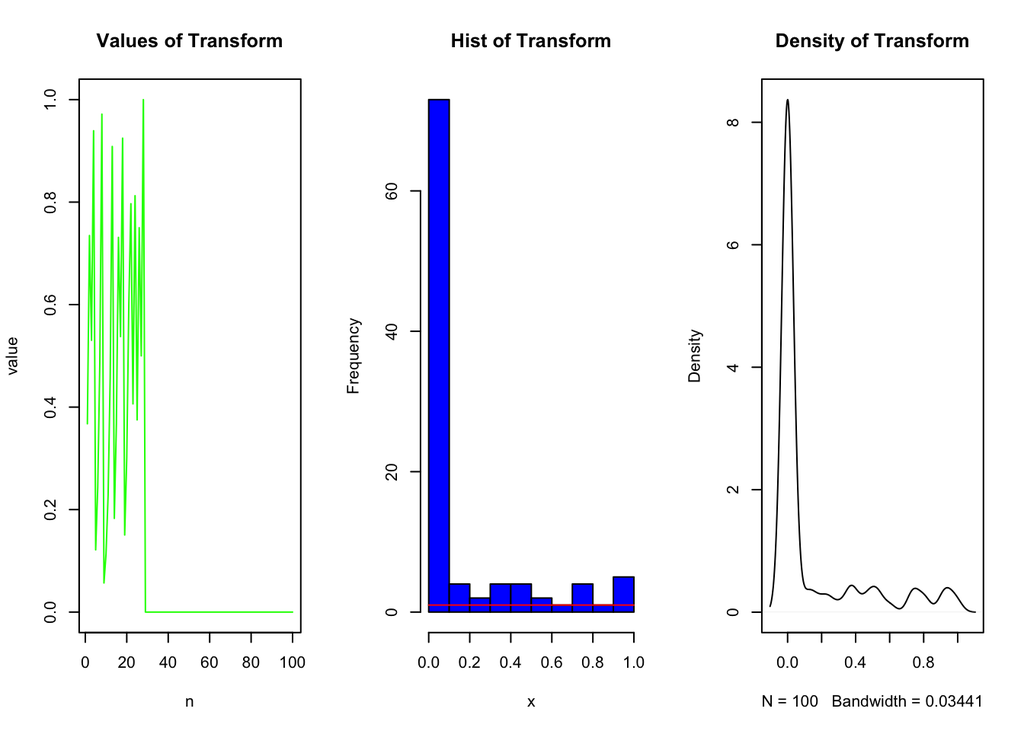

### Part 3

The resulting sequence has desirible behavior considering that most of values are edge cases.

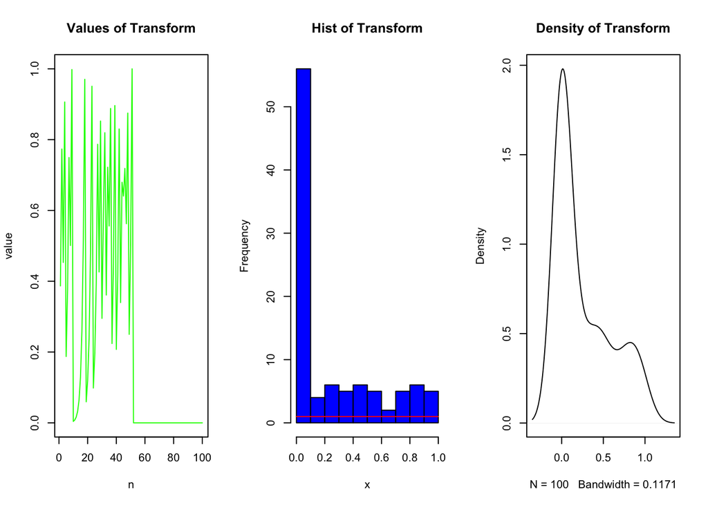